# EXST 7014: lab5 Assignment

Somnath Mukherjee

February 19, 2019

### Lab set-up

```r
#read input file
asphalt = read.table(here('lab5','data','data5.txt'), header = T, sep = " ",dec = ".") #use here() function to specify path
str(asphalt)
```

```
## 'data.frame':    20 obs. of  6 variables:
##  $ obs: int  1 2 3 4 5 6 7 8 9 10 ...
##  $ x1 : num  5.3 5.3 5.3 6 7.8 8 8 8 8 8 ...
##  $ x2 : num  0.02 0.02 0.02 2 0.2 2 2 2 2 0.02 ...
##  $ x3 : int  77 32 0 77 77 104 77 32 0 104 ...
##  $ y1 : Factor w/ 19 levels ".","194","22",..: 6 8 10 12 7 2 11 19 17 4 ...
##  $ y2 : Factor w/ 20 levels ".","0","0.04",..: 16 8 5 10 17 15 14 6 2 18 ...
```

```r
asphalt$y1 = as.numeric(as.character(asphalt$y1))
asphalt$y2 = as.numeric(as.character(asphalt$y2))
attach(asphalt)
```

### 1. Use the function lm to fit the multiple linear regression model Y2 = β0 + β1X1 + β2X2+ β3X3 + ε.Write down the estimated regression equation. What hypothesis does the F-test in ANOVA table test? What is the conclusion based on the ANOVA table?

```r
model1 <- lm(y2 ~ x1+x2+x3, x=T)
summary(model1)
```

```
##
## Call:
## lm(formula = y2 ~ x1 + x2 + x3, x = T)
##
## Residuals:
##     Min      1Q  Median      3Q     Max
## -3.5466 -1.4827 -0.1190  0.6097  5.0135
##
## Coefficients:
##             Estimate Std. Error t value Pr(>|t|)
## (Intercept) -5.61130    2.04575  -2.743 0.015100 *
## x1           0.66754    0.21168   3.154 0.006558 **
## x2          -1.23535    0.57949  -2.132 0.049966 *
## x3           0.07319    0.01438   5.090 0.000133 ***
## ---
## Signif. codes:  0 '***' 0.001 '**' 0.01 '*' 0.05 '.' 0.1 ' ' 1
##
## Residual standard error: 2.241 on 15 degrees of freedom
##   (1 observation deleted due to missingness)
## Multiple R-squared:  0.7601, Adjusted R-squared:  0.7121
## F-statistic: 15.84 on 3 and 15 DF,  p-value: 6.447e-05
```

Based on the table above our estimated regression equation is:  
Y2_Predicted = -5.611 + 0.667X1 - 1.23X2 + 0.073X3  
The hypotheses in F-test for the ANOVA table checks for regression effect which can be written as:  
H0: β1 = β2 = β3 = 0  
H1: At least one of the β is not equal to zero.  
Now based on the data above we get for F-statistic: 15.84 on 3 and 15 DF, p-value: 6.447e-05, which is much less than alpha of 0.05.  
Hence we will reject our null hypothese and conclude that at least one of the β is not equal to zero.

### 2. Are the regression coefficients significant? Are they consistent with the F test in question 1?

Considering an alpha level of 0.05 as cutoff for significance and based on the data above, we can conclude that all of the regression co-efficients are significant. To determine, we look at the p-value from individual t-test presented in the last column [Pr(>|t|)].  
The result is consistent with joint-test for partial regression coefficients(see Q1 above) presented with F-statistics.  
[NOTE: This can be an early indicator that we might not have multicollinerity problem.]

### 3. Suppose that there is a specimen with X1 = 9, X2 = 2.0 and X3 = 83. Estimate the strain of the specimen as well as its 95% confidence interval.

```r
predict(model1,data.frame(x1 = 9, x2 = 2, x3 = 83),interval="prediction") #confidence for fitted at 95%
```

```
##        fit       lwr      upr
## 1 4.000804 -1.210063 9.211671
```

### 4. What are the assumptions of the fitted model? Evaluate those assumptions by using proper R output.

The assumptions are similar to that of SLR as:  
*1.Normality of residuals*

```r
ols_test_normality(model1)
```

```
## -----------------------------------------------
##        Test             Statistic       pvalue
## -----------------------------------------------
## Shapiro-Wilk              0.9556         0.4888
## Kolmogorov-Smirnov        0.1685         0.5948
## Cramer-von Mises          1.2602          4e-04
## Anderson-Darling          0.3775         0.3729
## -----------------------------------------------
```

Based on the Shapiro-Wilk test value of 0.48 (> 0.05), we can assume normality of residual is preserved.  
*2. Homogenity of variance.*

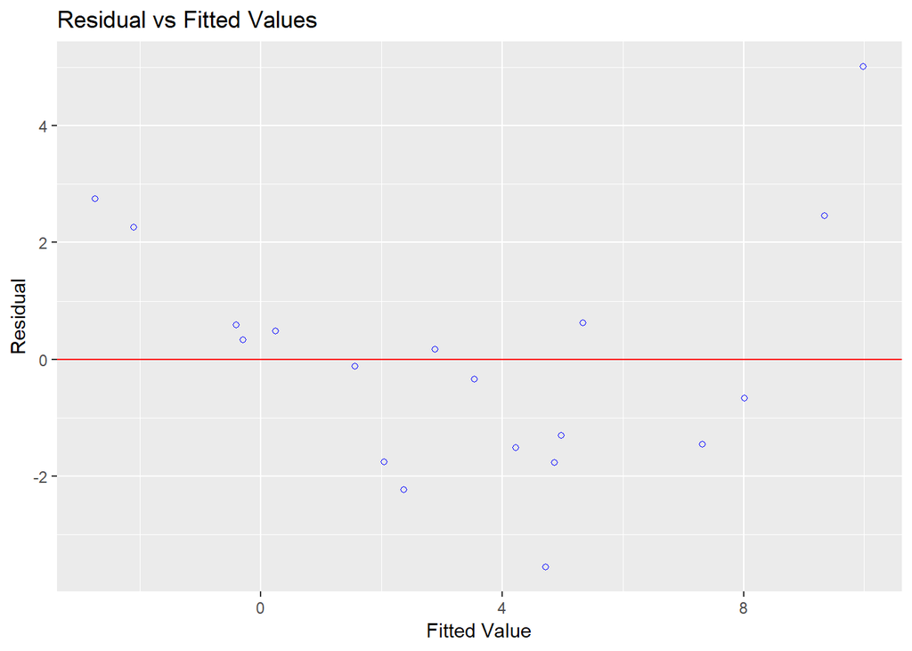

```r
ols_plot_resid_fit(model1)
```

### 5. Fit necessary models to find SS (X3|X1, X2) and SS (X3|X2).

```r
an1=Anova(model1, type="II") # Will help us compute the (type II) SS
an1
```

```
## Anova Table (Type II tests)
##
## Response: y2
##            Sum Sq Df F value   Pr(>F)
## x1         49.937  1  9.9451 0.006558 **
## x2         22.820  1  4.5446 0.049966 *
## x3        130.107  1 25.9110 0.000133 ***
## Residuals  75.319 15
## ---
## Signif. codes:  0 '***' 0.001 '**' 0.01 '*' 0.05 '.' 0.1 ' ' 1
```

SS (X3|X1, X2) = SS of X3 given X1 and X2. From the above table we get it as 130.107.

```r
model2 <- lm(y2 ~ x2+x3, x=T) # This is the reduced multilinear regression model.
an2=Anova(model2, type="II") # Will help us compute the (type II) SS
an2
```

```
## Anova Table (Type II tests)
##
## Response: y2
##            Sum Sq Df F value    Pr(>F)
## x2         41.992  1  5.3639 0.0341516 *
## x3        162.704  1 20.7834 0.0003219 ***
## Residuals 125.257 16
## ---
## Signif. codes:  0 '***' 0.001 '**' 0.01 '*' 0.05 '.' 0.1 ' ' 1
```

SS (X3|X2) = SS of X3 given X2. From the table above we get that as 162.704.

### 6. Is there indication of any possible problem of multicollinearity? Support your answer with proper R output.

```r
ols_coll_diag(model1) # Collinearity diagnostics table
```

```
## Tolerance and Variance Inflation Factor
## ---------------------------------------
## # A tibble: 3 x 3
##   Variables Tolerance   VIF
##   <chr>         <dbl> <dbl>
## 1 x1            0.934  1.07
## 2 x2            0.940  1.06
## 3 x3            0.961  1.04
##
##
## Eigenvalue and Condition Index
## ------------------------------
##   Eigenvalue Condition Index   intercept          x1          x2
## 1 3.16035424        1.000000 0.005883997 0.006414282 0.031476703
## 2 0.59252551        2.309481 0.003980755 0.010950409 0.875113666
## 3 0.21158028        3.864829 0.039785403 0.056345566 0.003156268
## 4 0.03553997        9.429949 0.950349845 0.926289743 0.090253363
##           x3
## 1 0.02401724
## 2 0.01865733
## 3 0.95564590
## 4 0.00167953
```

There is no value with **Condition Index** greater than 30. Hence there is no appearent problem of multicollinearity.

```r
ols_vif_tol(model1) # VIF computation
```

```
## # A tibble: 3 x 3
##   Variables Tolerance   VIF
##   <chr>         <dbl> <dbl>
## 1 x1            0.934  1.07
## 2 x2            0.940  1.06
## 3 x3            0.961  1.04
```

There is no **VIF** value which is greater than 10 and the avgerage VIF is also not greater than 2.  
Hence there is no appearent problem of multicollinearity.

### 7. Examine each F-test of parameter estimates with different type of SS. Which F-test results are identical to the results of T-test for parameter estimates? What is relationship between F-value and Tvalue?

```r
anv1=anova(model1) # Sequential (type I) SS
anv1
```

```
## Analysis of Variance Table
##
## Response: y2
##           Df  Sum Sq Mean Sq F value    Pr(>F)
## x1         1  98.419  98.419 19.6002 0.0004895 ***
## x2         1  10.111  10.111  2.0136 0.1763417
## x3         1 130.107 130.107 25.9110 0.0001330 ***
## Residuals 15  75.319   5.021
## ---
## Signif. codes:  0 '***' 0.001 '**' 0.01 '*' 0.05 '.' 0.1 ' ' 1
```

```r
anv2=Anova(model1, type="II") # Will help us compute the (type II) SS
anv2
```

```
## Anova Table (Type II tests)
##
## Response: y2
##            Sum Sq Df F value   Pr(>F)
## x1         49.937  1  9.9451 0.006558 **
## x2         22.820  1  4.5446 0.049966 *
## x3        130.107  1 25.9110 0.000133 ***
## Residuals  75.319 15
## ---
## Signif. codes:  0 '***' 0.001 '**' 0.01 '*' 0.05 '.' 0.1 ' ' 1
```

```r
anv3=Anova(model1, type="III") # Will help us compute the (type III) SS
anv3
```

```
## Anova Table (Type III tests)
##
## Response: y2
##              Sum Sq Df F value   Pr(>F)
## (Intercept)  37.778  1  7.5235 0.015100 *
## x1           49.937  1  9.9451 0.006558 **
## x2           22.820  1  4.5446 0.049966 *
## x3          130.107  1 25.9110 0.000133 ***
## Residuals    75.319 15
## ---
## Signif. codes:  0 '***' 0.001 '**' 0.01 '*' 0.05 '.' 0.1 ' ' 1
```

Compare with multiple regression model:

```r
summary(model1)
```

```
##
## Call:
## lm(formula = y2 ~ x1 + x2 + x3, x = T)
##
## Residuals:
##     Min      1Q  Median      3Q     Max
## -3.5466 -1.4827 -0.1190  0.6097  5.0135
##
## Coefficients:
##             Estimate Std. Error t value Pr(>|t|)
## (Intercept) -5.61130    2.04575  -2.743 0.015100 *
## x1           0.66754    0.21168   3.154 0.006558 **
## x2          -1.23535    0.57949  -2.132 0.049966 *
## x3           0.07319    0.01438   5.090 0.000133 ***
## ---
## Signif. codes:  0 '***' 0.001 '**' 0.01 '*' 0.05 '.' 0.1 ' ' 1
##
## Residual standard error: 2.241 on 15 degrees of freedom
##   (1 observation deleted due to missingness)
## Multiple R-squared:  0.7601, Adjusted R-squared:  0.7121
## F-statistic: 15.84 on 3 and 15 DF,  p-value: 6.447e-05
```

By looking at the tables above we can conclude:  
1. The F-test p-values for TYPE-|| and TYPE-||| SS matches exactly with regression model T-test p-values. However, for TYPE-| we see a mismatch.  
2. The *square* of t-value in regression model is equal to the F-value for TYPE-|| and TYPE-||| SS.